# Hands-on Voriconazole PBPK Model

Metrum Research Group

# Reference

Zane NR, Thakker DR. A physiologically based pharmacokinetic model for voriconazole disposition predicts intestinal first-pass metabolism in children. Clin Pharmacokinet. 2014;53: 1171–1182  
https://link.springer.com/article/10.1007%2Fs40262-014-0181-y

# Voriconazole PBPK Model Structure

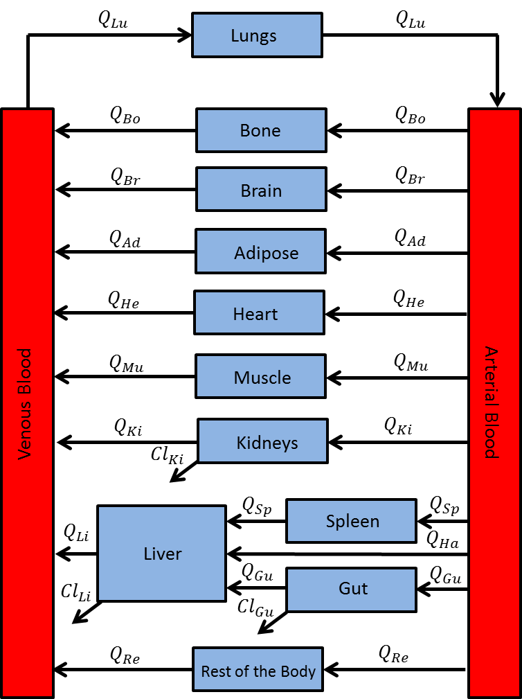

# Tasks

**Note:** for the following tasks use `hands-on_voriPBPK_script.R`

1. Use `voriPBPK.cpp` model file to complete the ODEs missing and compile the model.
2. Use `CalcKp_P&T.R` function to calculate voriconzole tissue:plasma partition coefficients according to Poulin and Theil method https://www.ncbi.nlm.nih.gov/pubmed/11782904.
3. Simulate the steady state after a 4 mg/kg IV infusion dose of voriconazole given to an adult male with a rate of 4 mg/kg/h twice a day for 7 days. Compare the steady state plasma drug concentration-time profiles from previous simulation to the observed data in `Adult_IV.csv`. (N.B.: observed data were digitized from Zane and Thakker (2014) paper using WebPlotDigitizer https://automeris.io/WebPlotDigitizer/):

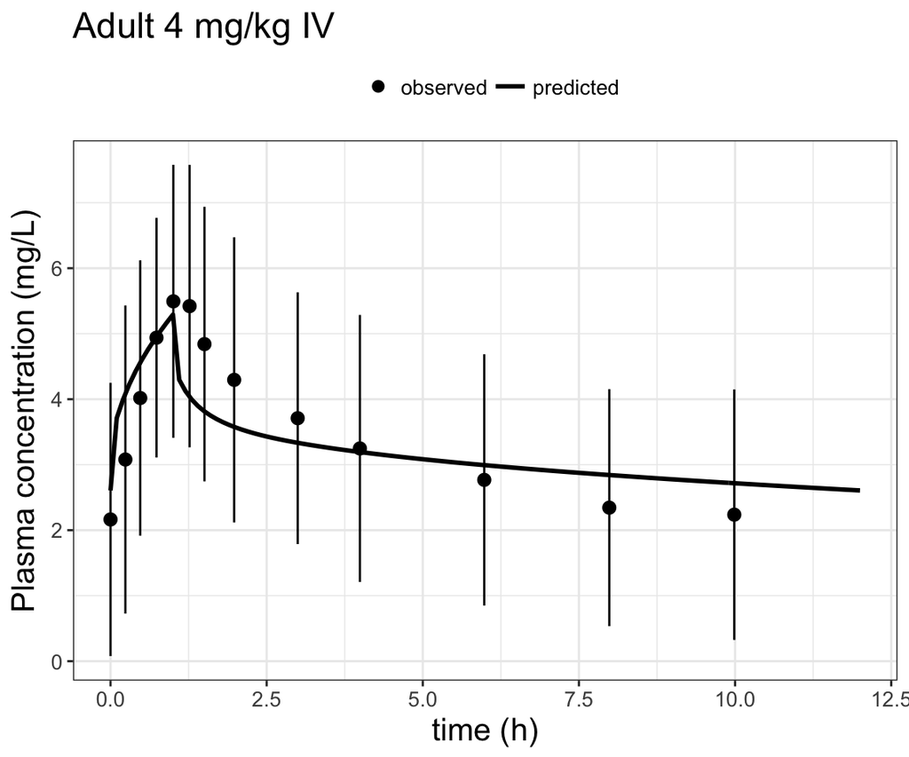

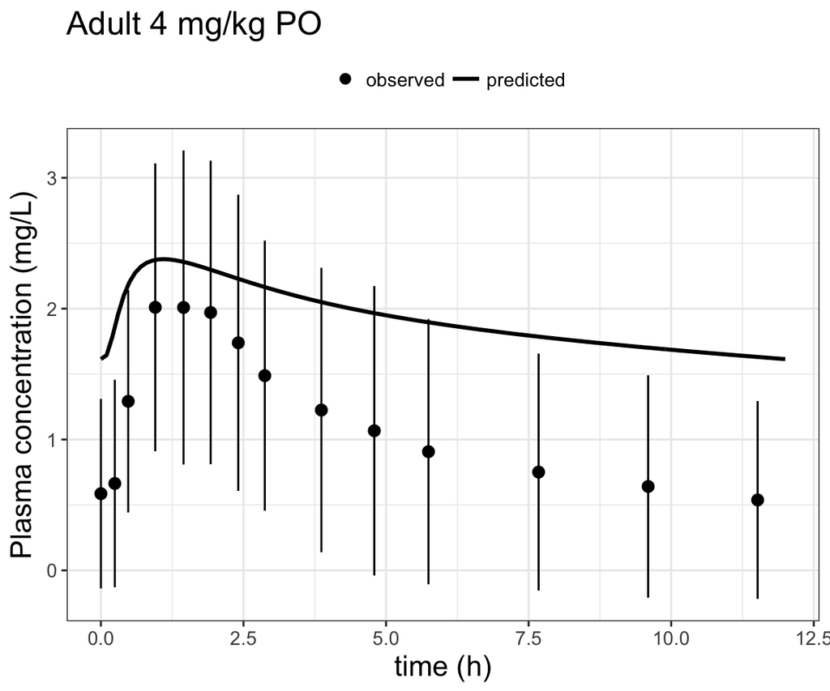

5. Integrate the model with an additional gut wall enterocyte compartment to account for intestinal clearance, intestinal transit and lumen solubility effects on absorption rate. Note: use about an intestinal clearance that is 30 times lower than hepatic clearance. Recompile and re-run the previous step. Any change!!

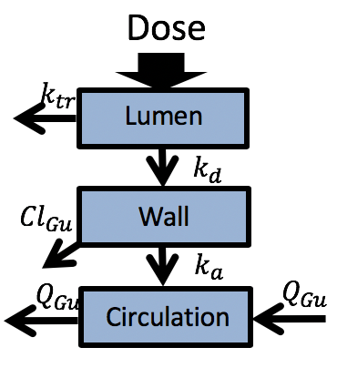

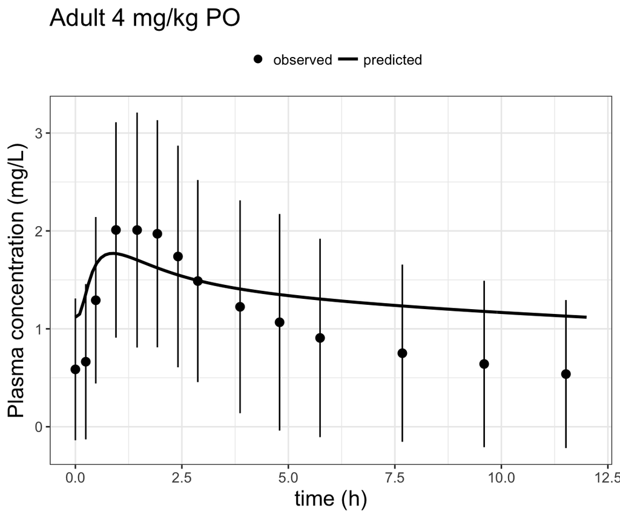

6. generate pediatric model.
7. Simulate the steady state after a 4 mg/kg voriconazole IV infusion dosing in a male child subject infused at a rate of 3 mg/kg/h twice a day for seven days. Compare the steady state to the observed data in `Pediatric_IV.csv`.

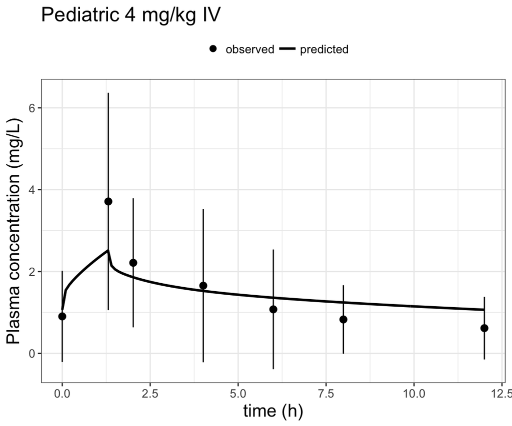

8. Simulate the steady state after a 4 mg/kg voriconazole PO dosing in a male child subject twice a day for seven days. Compare to obsreved data in `Pediatric_PO.csv` Note: Include a similar 30-fold lower intestinal clearance than hepatic clearance.

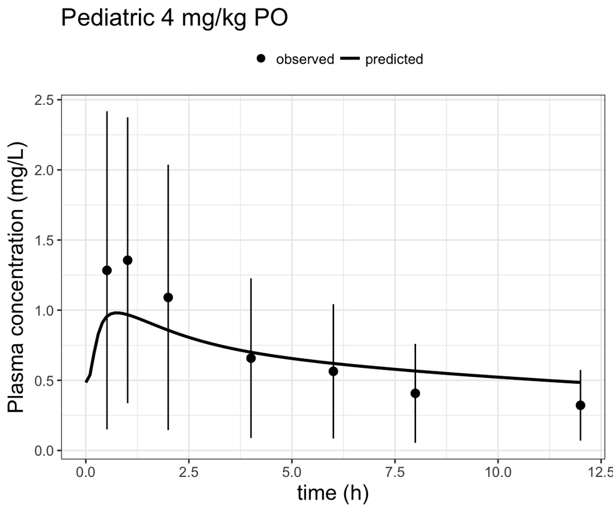

9. Run graphical sensitivity analysis for the muscle:plasma (`Kpmu`) and lung:plasma (`Kplu`) partition coefficients using adult IV data.

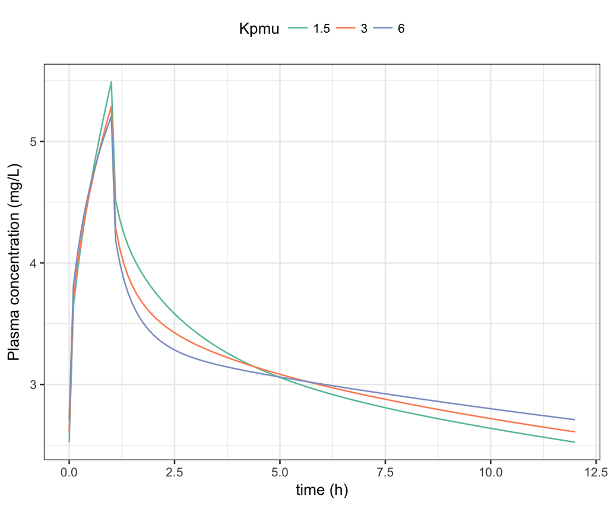

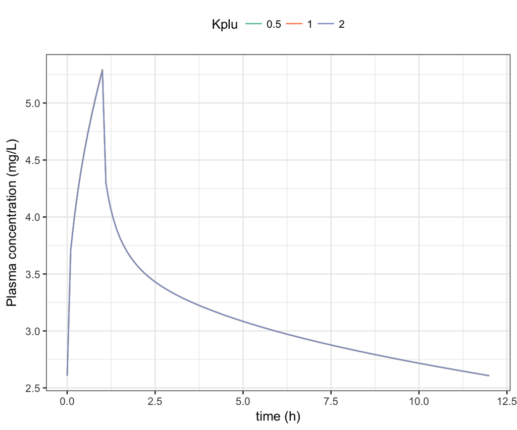

10. Use package `FME` (https://cran.r-project.org/web/packages/FME/index.html) to run local sensitivity analysis for the partition coefficient parameters using the FME package. What is the most influential parameter?

```
.      value scale      L1      L2     Mean     Min     Max   N
. Kpad  9.89  9.89 0.00436 4.6e-04  0.00011 -0.0058 0.01186 121
. Kpbo  7.91  7.91 0.00860 9.0e-04  0.00036 -0.0114 0.02096 121
. Kpbr  7.35  7.35 0.00735 9.4e-04  0.00145 -0.0339 0.00724 121
. Kpgu  5.82  5.82 0.00234 3.7e-04  0.00010 -0.0159 0.00309 121
. Kphe  1.95  1.95 0.00048 8.6e-05 -0.00028 -0.0047 0.00103 121
. Kpki  2.90  2.90 0.00075 1.1e-04 -0.00017 -0.0061 0.00221 121
. Kpli  4.66  4.66 0.00550 7.6e-04  0.00109 -0.0310 0.00665 121
. Kplu  0.83  0.83 0.00032 3.7e-05  0.00012 -0.0014 0.00061 121
. Kpmu  2.94  2.94 0.03746 3.9e-03  0.00412 -0.0824 0.05345 121
. Kpsp  2.96  2.96 0.00056 6.0e-05  0.00027 -0.0019 0.00092 121
```

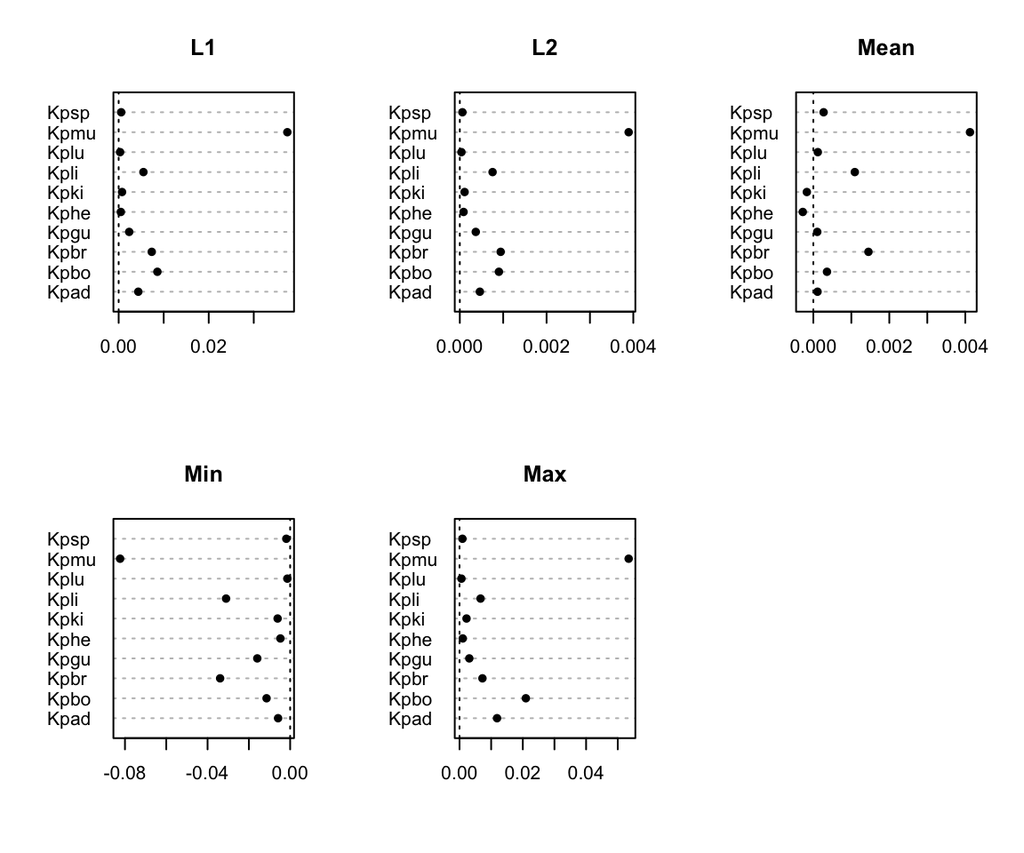

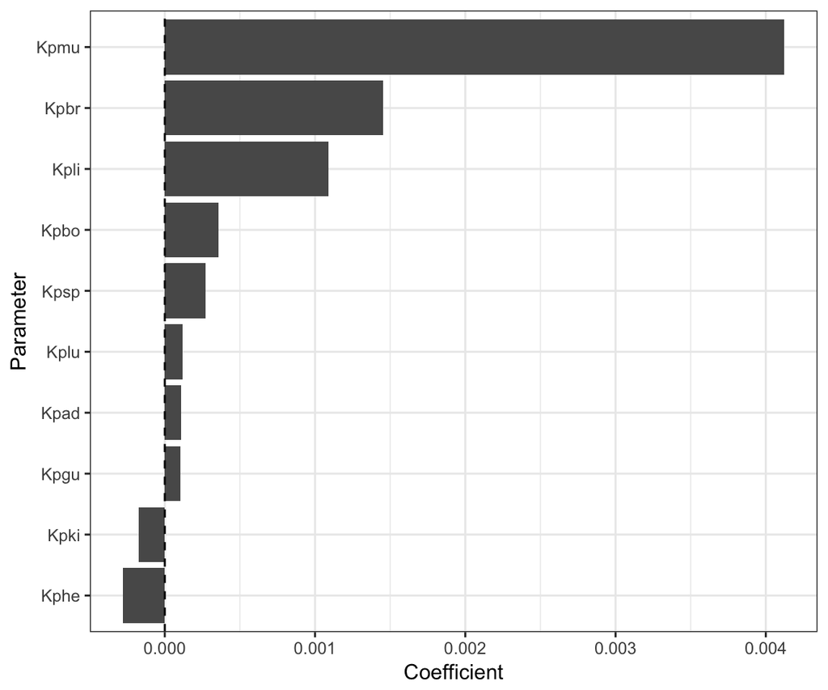

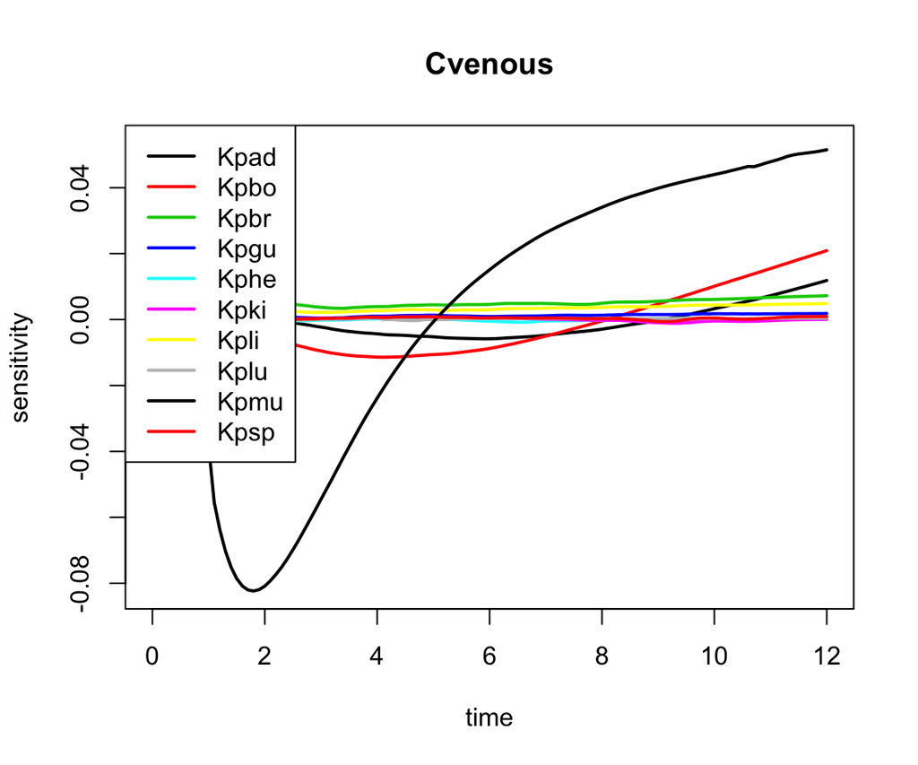

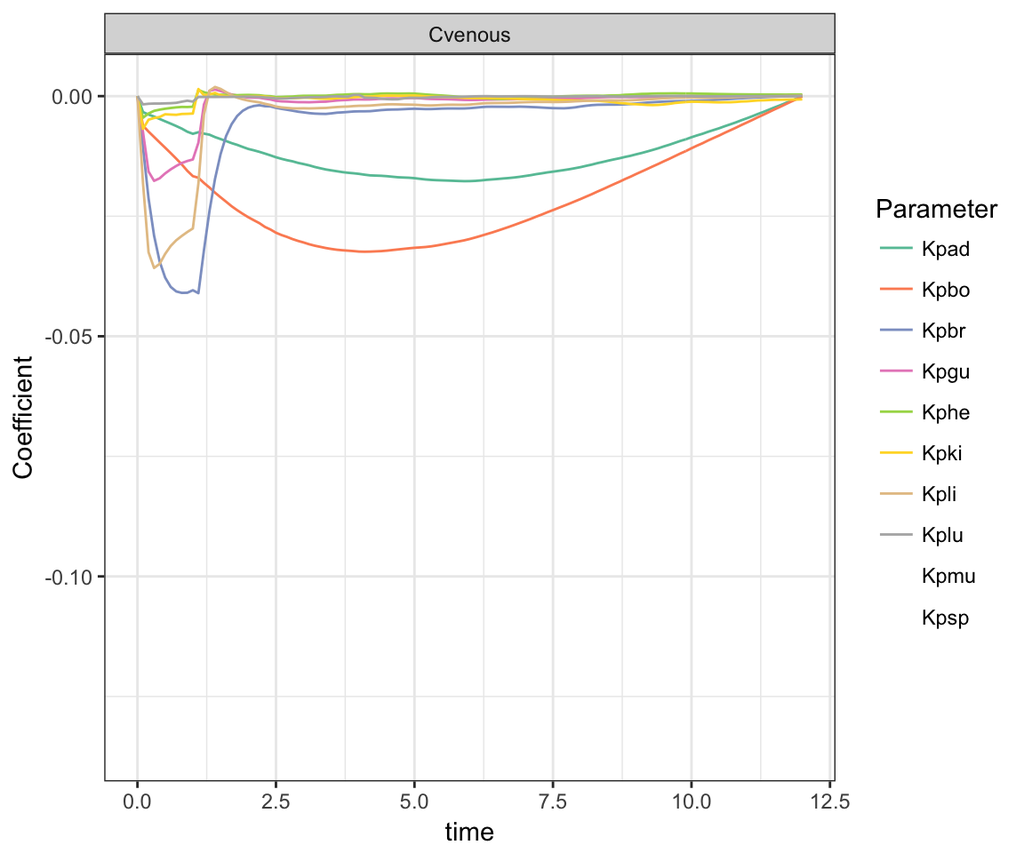

11. Use package `nloptr` (https://cran.r-project.org/web/packages/nloptr/index.html) to optimize for most influential partition coefficient parameter and compare prediction before and after optimization to observed data.

```
. $par
. [1] -0.5714212 -2.0483519
.
. $value
. [1] -8.181854
.
. $iter
. [1] 103
.
. $convergence
. [1] 4
.
. $message
. [1] "NLOPT_XTOL_REACHED: Optimization stopped because xtol_rel or xtol_abs (above) was reached."
```

```
. $Kpmu
. [1] 0.5647223
.
. $sigma
. [1] 0.1289472
```

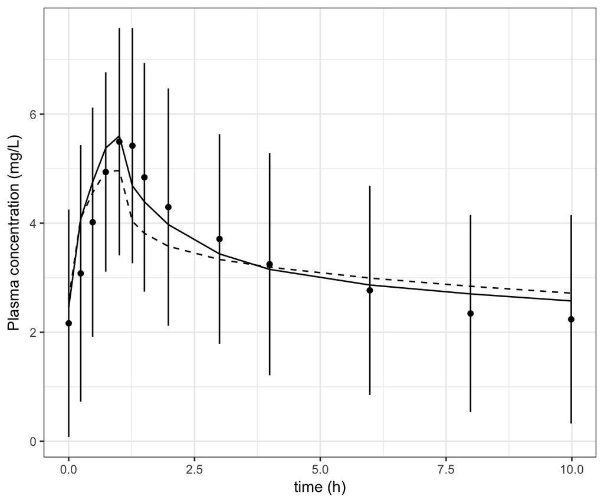

12. Simulate a 4 mg/kg voriconazole IV infusion dosing in a male child subject infused at a rate of 3 mg/kg/h twice a day for seven days. Compare the steady state prediction before and after optimization to the observed data in `Pediatric_IV.csv`.

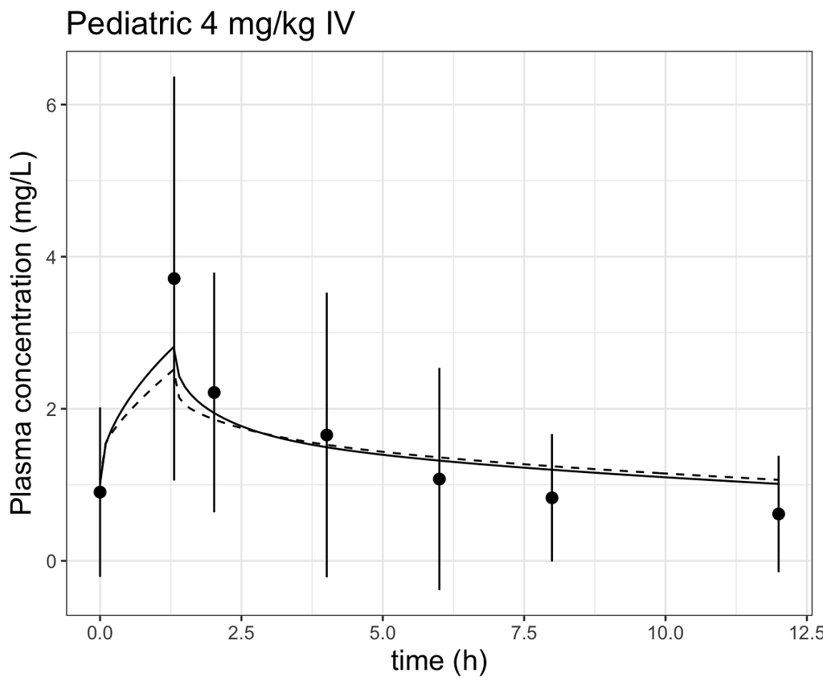